# P2-Titanic-Final2

### 1. Introduction

The Titanic passenger data was analyzed for this project. The questions explored are:

1. What was the difference in survival between male and female passengers?
2. How did survival vary between passenger classes?
3. What is the correlation between age and survival?
4. Did survival between passengers from different ports of embarkation vary?

### 2. Data import, check data types and limitations

The data was first imported from the provided Titanic csv file. The data types for some of the columns did not match the data. For example, 'PassengerId' and 'Pclass' were imported as integers. However, this will not affect the analysis as calculations will not be perfomed on these values.

In addition, 20 % of the age data was missing from the data. This is a limitation on the analysis of age and survival which will be shown later. The pandas functions used in the analysis (groupby, mean, sum and count) ignore missing (NaN) values in grouping and calculations.

```python
#import numpy and pandas libraries
import numpy as np
import pandas as pd
#import data from csv file
titanic = pd.read_csv('titanic-data.csv')
#view sample of data after importing. NaN values in Age and Cabin columns are seen.
print titanic.tail(10)
```

```
     PassengerId  Survived  Pclass                                      Name  \
881          882         0       3                        Markun, Mr. Johann
882          883         0       3              Dahlberg, Miss. Gerda Ulrika
883          884         0       2             Banfield, Mr. Frederick James
884          885         0       3                    Sutehall, Mr. Henry Jr
885          886         0       3      Rice, Mrs. William (Margaret Norton)
886          887         0       2                     Montvila, Rev. Juozas
887          888         1       1              Graham, Miss. Margaret Edith
888          889         0       3  Johnston, Miss. Catherine Helen "Carrie"
889          890         1       1                     Behr, Mr. Karl Howell
890          891         0       3                       Dooley, Mr. Patrick

        Sex   Age  SibSp  Parch            Ticket     Fare Cabin Embarked
881    male  33.0      0      0            349257   7.8958   NaN        S
882  female  22.0      0      0              7552  10.5167   NaN        S
883    male  28.0      0      0  C.A./SOTON 34068  10.5000   NaN        S
884    male  25.0      0      0   SOTON/OQ 392076   7.0500   NaN        S
885  female  39.0      0      5            382652  29.1250   NaN        Q
886    male  27.0      0      0            211536  13.0000   NaN        S
887  female  19.0      0      0            112053  30.0000   B42        S
888  female   NaN      1      2        W./C. 6607  23.4500   NaN        S
889    male  26.0      0      0            111369  30.0000  C148        C
890    male  32.0      0      0            370376   7.7500   NaN        Q
```

```python
#View summary statistics of overall dataset.
titanic.describe()
```

|  | PassengerId | Survived | Pclass | Age | SibSp | Parch | Fare |
| --- | --- | --- | --- | --- | --- | --- | --- |
| count | 891.000000 | 891.000000 | 891.000000 | 714.000000 | 891.000000 | 891.000000 | 891.000000 |
| mean | 446.000000 | 0.383838 | 2.308642 | 29.699118 | 0.523008 | 0.381594 | 32.204208 |
| std | 257.353842 | 0.486592 | 0.836071 | 14.526497 | 1.102743 | 0.806057 | 49.693429 |
| min | 1.000000 | 0.000000 | 1.000000 | 0.420000 | 0.000000 | 0.000000 | 0.000000 |
| 25% | 223.500000 | 0.000000 | 2.000000 | 20.125000 | 0.000000 | 0.000000 | 7.910400 |
| 50% | 446.000000 | 0.000000 | 3.000000 | 28.000000 | 0.000000 | 0.000000 | 14.454200 |
| 75% | 668.500000 | 1.000000 | 3.000000 | 38.000000 | 1.000000 | 0.000000 | 31.000000 |
| max | 891.000000 | 1.000000 | 3.000000 | 80.000000 | 8.000000 | 6.000000 | 512.329200 |

```python
# View data types in columns. Though columns such as PassengerId and Pclass are imported
# as integers instead of strings, this won't affect the analysis.
titanic.dtypes
```

```
PassengerId      int64
Survived         int64
Pclass           int64
Name            object
Sex             object
Age            float64
SibSp            int64
Parch            int64
Ticket          object
Fare           float64
Cabin           object
Embarked        object
dtype: object
```

```python
# Calculate number of null values in data set.
pd.isnull(titanic).sum()
```

```
PassengerId      0
Survived         0
Pclass           0
Name             0
Sex              0
Age            177
SibSp            0
Parch            0
Ticket           0
Fare             0
Cabin          687
Embarked         2
dtype: int64
```

```python
# Calculate total number of passengers.
total_passengers = titanic['PassengerId'].count()
# Calculate percentages of missing age and cabin data
percent_age_missing = float(pd.isnull(titanic['Age']).sum())/float(total_passengers) * 100
percent_cabin_missing = float(pd.isnull(titanic['Cabin']).sum())/float(total_passengers) * 100
print percent_age_missing
print percent_cabin_missing
```

```
19.8653198653
77.1043771044
```

### 3. What was the difference in survival between male and female passengers?

There was a difference in the survival rate between male and female passengers. 74% of female passengers survived while 19% of male passengers survived. The plot below shows the number of passengers that survived for each gender and the total number of passengers.

```
        Survived  Total    Average
Sex
female       233    314  74.203822
male         109    577  18.890815
```

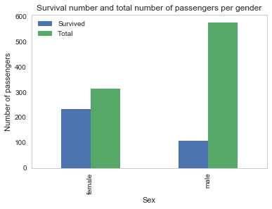

```python
# import matplotlib and seaborn
import matplotlib.pyplot as plt
import seaborn as sns

# Group titanic data by gender. Calculate survival number and total passengers by gender
titanic_df = pd.DataFrame(titanic)
titanic_gender = titanic_df.groupby('Sex')
titanic_gender_survived = titanic_gender['Survived'].sum()
titanic_gender_total = titanic_gender['Survived'].count()

##convert survival number and total passengers by gender to dataframes
titanic_gender_survived_df = pd.DataFrame(titanic_gender_survived)
titanic_gender_total_df = pd.DataFrame(titanic_gender_total)

#change column name to Total for total passengers dataframe
titanic_gender_total_df.columns = ['Total']

#combine the survival number and total passengers by gender into one dataframe
all_data_gender = titanic_gender_survived_df.join(titanic_gender_total_df, how = 'outer')

#calculate the survival percentage for male and female passengers
gender_rate = titanic_df.groupby('Sex')['Survived'].mean() * 100
gender_rate = pd.DataFrame(gender_rate, index = ['female', 'male'])
gender_rate.columns = ['Average']

#add rate date to survival and total dataframe
all_data_gender_rate = all_data_gender.join(gender_rate, how = 'outer')
print all_data_gender_rate

#plot survival and total dataframe
%pylab inline
ax = all_data_gender.plot.bar(title = 'Survival number and total number of passengers per gender')
ax.set_ylabel('Number of passengers')
```

### 4. How did survival vary between passenger classes?

The survival numbers across the three different passenger classes were explored. Due to the discrepancy in survival between male and female passengers, the data for each class was explored by gender.

The survival rate between male and female passengers in each class was plotted as shown below. This showed that more than 90% of female passengers in the first and second class survived, while about 50% of female passengers in the third class survived. The survival rate for male passengers was lower. About 35% of first class male passengers survived and about 15% of second and third class male passengers survived.

```
        Total  Survived
Pclass
1         216       136
2         184        87
3         491       119
```

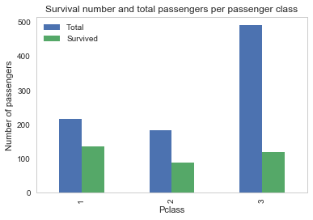

```python
#Group titanic data by passenger class. Calculate survival number and total passengers
# by passenger class.
titanic_class = titanic_df.groupby('Pclass')
titanic_class_survived = titanic_class['Survived'].sum()
titanic_class_total = titanic_class['Survived'].count()

#Convert survival number and total passengers to dataframes.
titanic_class_survived_df = pd.DataFrame(titanic_class_survived)
titanic_class_total_df = pd.DataFrame(titanic_class_total)

#Change total passengers dataframe column to Total
titanic_class_total_df.columns = ['Total']

#Combine survival number and total passenger dataframes into one dataframe.
all_data_class = titanic_class_total_df.join(titanic_class_survived_df, how = 'outer')
print all_data_class

#plot survival and total dataframe by class
%pylab inline
ax = all_data_class.plot.bar(title = 'Survival number and total passengers per passenger class')
ax.set_ylabel('Number of passengers')
```

[figure not shown]

```python
#Filter titanic data by gender and convert to dataframe
titanic_female = titanic[titanic['Sex']== 'female']
titanic_male = titanic[titanic['Sex']== 'male']
titanic_female_df = pd.DataFrame(titanic_female)
titanic_male_df = pd.DataFrame(titanic_male)

#Group gender dataframes by passenger class and calculate survival rate
titanic_female_class = titanic_female_df.groupby(['Pclass'])['Survived'].mean()
titanic_male_class = titanic_male_df.groupby(['Pclass'])['Survived'].mean()

#Set index for plotting
class_index = ['1', '2', '3']

#plot female and male data per class
%pylab inline
plt.plot(class_index, female_rate, '-o')
plt.plot(class_index, male_rate, '-o')
plt.xlabel('Passenger Class')
plt.ylabel('% Survival')
plt.legend(['Female', 'Male'])
plt.xticks([1,2,3])
plt.ylim(0,100)
plt.yticks(range(0,101,10))
plt.title('Percent survival for female and male passengers across passenger classes')
```

### 5. What is the correlation between age and survival?

In order to examine any correlation between age and survival, the number of passengers per age group was first plotted as shown below. The ages were divided into groups every 10 years starting at age 0. The average age was 29.7 years with a standard deviation of 14.5 years. The median age was 28.0 years. The age distribution was fairly normal as reflected in the close mean and median values and the age distribution plot below.

One limitation of this analysis is that there were only 19 records for passengers from 60-70 years old and 6 records for passengers from 70-80 years old. A second limitation is that 20% (177 records) of passenger records were missing age information.

```
count    714.000000
mean      29.699118
std       14.526497
min        0.420000
25%       20.125000
50%       28.000000
75%       38.000000
max       80.000000
Name: Age, dtype: float64
Age
[0, 10)     61.290323
[10, 20)    40.196078
[20, 30)    35.000000
[30, 40)    43.712575
[40, 50)    38.202247
[50, 60)    41.666667
[60, 70)    31.578947
[70, 80)     0.000000
Name: Survived, dtype: float64
          PassengerId  Survived  Pclass  Name  Sex  Age  SibSp  Parch  Ticket  \
Age
[0, 10)            62        62      62    62   62   62     62     62      62
[10, 20)          102       102     102   102  102  102    102    102     102
[20, 30)          220       220     220   220  220  220    220    220     220
[30, 40)          167       167     167   167  167  167    167    167     167
[40, 50)           89        89      89    89   89   89     89     89      89
[50, 60)           48        48      48    48   48   48     48     48      48
[60, 70)           19        19      19    19   19   19     19     19      19
[70, 80)            6         6       6     6    6    6      6      6       6

          Fare  Cabin  Embarked
Age
[0, 10)     62     10        62
[10, 20)   102     19       102
[20, 30)   220     36       220
[30, 40)   167     50       166
[40, 50)    89     33        89
[50, 60)    48     24        48
[60, 70)    19     10        18
[70, 80)     6      2         6
```

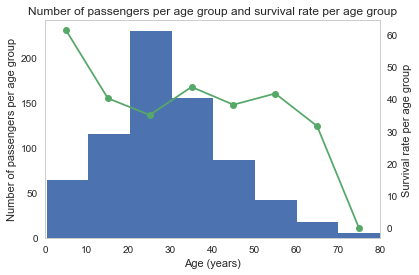

```python
#Age data from titanic and descriptive statistics

titanic_age = titanic['Age']
print titanic_age.describe()

#Create age categories
category_age = pd.cut(titanic['Age'], range(0, 81, 10), right = False)

#Calculate survival rate per age group
survival_all_ages = titanic_df.groupby(category_age)['Survived'].mean() *100
print survival_all_ages

#print number of age records for passengers in each category
print titanic_df.groupby(category_age).count()

#set age index for plot
age_index = [5, 15, 25, 35, 45, 55, 65, 75]

#convert to Series
survival_all_ages = pd.Series(survival_all_ages.values, index = age_index)

#plot titanic passenger age data
%pylab inline
sns.set_style("whitegrid", {'axes.grid' : False})
ax =titanic_age.plot.hist(bins = 8, title = 'Number of passengers per age group and survival rate per age group')
ax.set_ylabel('Number of passengers per age group')
ax.set_xlabel('Age (years)')
#plot survival rate per age group
ax2 = survival_all_ages.plot( secondary_y = True, style = '-o', xlim = [0,80])
ax2.set_ylabel('Survival rate per age group')
```

### 6. Did survival between passengers from different ports of embarkation vary?

The differences in survival between passengers originating from different ports of embarkation was analyzed. The passengers originated from the ports of Cherbourg (C), Queenstown (Q), Southampton (S). The graphs below show the percentage of passengers who survived for each port and the survival number and total number of passengers.

Passengers originating from Cherbourg had the highest survival rate of 55%, while the passengers originating from Queenstown and Southampton had lower survival rates of 39 and 34% respectively. The majority of passengers (72%) originated from Southampton.

```
0.724409448819
          Survived  Total
Embarked
C               93    168
Q               30     77
S              217    644
[ 55.35714286  38.96103896  33.69565217]
```

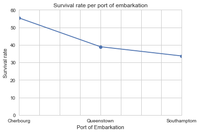

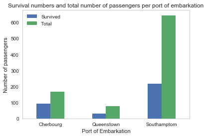

```python
# Group data by port of embarkation and calculate survival and total numbers
titanic_embarked = titanic_df.groupby('Embarked')
embarked_survived = titanic_embarked['Survived'].sum()
embarked_total = titanic_embarked['Survived'].count()

#Convert survival and total numbers to dataframe. Set total dataframe column name to Total
embarked_survived_df = pd.DataFrame(embarked_survived)
embarked_total_df = pd.DataFrame(embarked_total)
embarked_total_df.columns = ['Total']

#Calculate % of passengers from Southampton
passengers_southampton = float(embarked_total_df.loc['S']['Total'])/float(embarked_total_df['Total'].sum())
print passengers_southampton

#Combine survival and total numbers dataframes into one dataframe.
embarked_survived_total = embarked_survived_df.join(embarked_total_df, how = 'outer')
print embarked_survived_total

#Ports correspond to: C = Cherbourg, Q = Queenstown, S = Southampton
#Calculate percent surival per port and create port index
survival_ports = titanic_df.groupby('Embarked')['Survived'].mean().values * 100
print survival_ports
port_index = ['Cherbourg', 'Queenstown', 'Southamptom']

#create series with class index
survival_ports = pd.Series(survival_ports, index = port_index)

#plot survival rate data
%pylab inline
ax = survival_ports.plot(ylim = [0,60], grid = True,title = 'Survival rate per port of embarkation', style = "-o")
ax.set_ylabel('Survival rate')
ax.set_xlabel('Port of Embarkation')

#plot passenger survival and total numbers
ax2 =embarked_survived_total.plot.bar(title = 'Survival numbers and total number of passengers per port of embarkation', rot = 0)
ax2.set_xlabel('Port of Embarkation')
ax2.set_ylabel('Number of passengers')
ax2.set_xticklabels(port_index)
```

### 8. Limitations

A limitation of this analysis is that 20% or 177 records were missing age information. In addition, there were less records for passengers aged 60-80 years old.

This analysis explores correlation between factors and does not imply causation.

### 9. References

1. http://pandas.pydata.org/pandas-docs/stable/visualization.html
2. http://stackoverflow.com/questions/26683654/making-a-stacked-barchart-in-pandas
3. http://pandas.pydata.org/pandas-docs/stable/generated/pandas.concat.html
4. http://pandas.pydata.org/pandas-docs/stable/generated/pandas.DataFrame.unstack.html
5. http://pandas.pydata.org/pandas-docs/stable/generated/pandas.DataFrame.plot.html
6. http://matplotlib.org/api/pyplot_api.html#matplotlib.pyplot.bar
7. http://pandas.pydata.org/pandas-docs/stable/generated/pandas.Series.values.html
8. http://pandas.pydata.org/pandas-docs/stable/generated/pandas.Series.add.html
9. http://pandas.pydata.org/pandas-docs/stable/generated/pandas.DataFrame.merge.html
10. http://stackoverflow.com/questions/11346283/renaming-columns-in-pandas
11. http://pandas.pydata.org/pandas-docs/stable/generated/pandas.DataFrame.groupby.html
12. http://pandas.pydata.org/pandas-docs/stable/indexing.html#query-use-cases
13. http://pandas.pydata.org/pandas-docs/stable/generated/pandas.DataFrame.set_index.html
14. http://pandas.pydata.org/pandas-docs/stable/generated/pandas.Series.html
15. http://pandas.pydata.org/pandas-docs/stable/generated/pandas.Series.filter.html
16. http://stackoverflow.com/questions/11869910/pandas-filter-rows-of-dataframe-with-operator-chaining
17. http://pandas.pydata.org/pandas-docs/stable/generated/pandas.DataFrame.applymap.html
18. http://pandas.pydata.org/pandas-docs/stable/generated/pandas.DataFrame.applymap.html
19. http://pandas.pydata.org/pandas-docs/stable/generated/pandas.DataFrame.applymap.html
20. http://seaborn.pydata.org/generated/seaborn.barplot.html#seaborn.barplot